# Communicating spatial frames with whole-body silent gesture

Descriptive statistics

Analysis by AĆ

20 sierpień, 2026

# 1 Introduction

This is the second script in the spatial-frames pipeline (the first, `1_preliminary.Rmd`, covered the semantic-distance work on the referent set). It describes the referential-game data. It fits nothing and tests nothing.

**The study.** Dyads play a referential game in which one partner (the *producer*) communicates a target referent to the other (the *guesser*) through whole-body silent gesture, and the guesser selects from a 16-image response matrix. The design is fully within-dyad, 2 (size: element vs. complete) × 2 (distance: proximate vs. displaced); every dyad completes all four conditions, 16 trials per dyad (one production of each of the 16 fixed stimuli), with producer and guesser roles alternating between partners.

**Two dependent measures.** *Communicative success* (`correct_target`, 1/0) is whether the guesser picked the right referent. *Representation strategy* is coded per production, and here the data depart from the preregistration: rather than a single icon-or-index label, each production carries three independent 0/1 flags — `icon`, `index`, and an unregistered third strategy, `prop` — and they can co-occur (a production may be coded icon *and* index). The modelling script therefore tests H2a and H2b as two separate Bernoulli models (`icon ~ .` and `index ~ .`), a principled deviation forced by discovering co-occurrence after preregistration; the registered single-binary Model A is retained there as a robustness check on the subset coded as exactly one of the two.

**What this script does.** It reads the annotation sheet, cleans it, derives the design variables from `story_id`, builds the unique person keys the models need, reports counts / balance / distributions / co-occurrence, and exports a prepared data frame for the modelling script. Everything the interpretation prose cites is stored in a named object, so the text tracks the data.

**Working on simulated data.** Until the empirical annotation arrives, `data_file` points at the simulated sheet, so every number below is placeholder. Swap that one path for the real coder file and nothing else changes.

# 2 Data preparation

## 2.1 Source setup

```r
########## folders ##########
setwd(dirname(rstudioapi::getActiveDocumentContext()$path))

parentfolder <- dirname(getwd())

data          <- paste0(parentfolder, '/data/')
models        <- paste0(parentfolder, '/models/')
plots         <- paste0(parentfolder, '/plots/')
scripts       <- paste0(parentfolder, '/scripts/')

#################### packages ####################
# Core tidyverse for wrangling + plotting; janitor/skimr for structure checks.
library(tidyverse)
library(janitor)
library(skimr)
library(readxl)
library(knitr)

# Keep plots/readability consistent
theme_set(theme_minimal(base_size = 12))

# use all available cores (harmless here; matches project setup)
options(mc.cores = parallel::detectCores())

colorBlindBlack8  <- c("#000000", "#E69F00", "#56B4E9", "#009E73",
                       "#F0E442", "#0072B2", "#D55E00", "#CC79A7")

# Figure and Table caption helpers (manual numbering for HTML):
outputFormat = opts_knit$get("rmarkdown.pandoc.to");
if( is.null(outputFormat) ) outputFormat = "";
capTabNo = 1; capFigNo = 1;
capTab = function(x){
  if(outputFormat == 'html'){
    x = paste0("**Table ",capTabNo,".** ",x,"")
    capTabNo <<- capTabNo + 1
  }; x
}
capFig = function(x){
  if(outputFormat == 'html'){
    x = paste0("**Figure ",capFigNo,".** ",x,"")
    capFigNo <<- capFigNo + 1
  }; x
}
```

## 2.2 Load in data

```r
# SWAP this one line for the real coder sheet when it arrives; if the real
# file has several coder sheets, add e.g. sheet = "coder_MS".
data_file <- paste0(data, "dataframe_consensus.xlsx")

df <- read_excel(data_file) %>%
  clean_names() %>%
  remove_empty(c("rows", "cols"))   # drops trailing empty rows / stray blank column

# --- FIX: pair11 participant mislabelling ----------------------------------- #
# The 11th dyad is p23 / p24; trials 1-2 were entered with stale IDs p21 / p22.
# Corrected here (not in the raw file) so the source sheet stays untouched and
# the correction is documented in the pipeline.
df <- df %>%
  mutate(
    participant = if_else(
      pair == "pair11",
      case_match(participant,
                 "p21" ~ "p23",
                 "p22" ~ "p24",
                 .default = participant),
      participant
    )
  )

# Peek at raw types and missingness
skim(df)
```

Data summary

| Name | df |
| --- | --- |
| Number of rows | 480 |
| Number of columns | 10 |
| _______________________ |  |
| Column type frequency: |  |
| character | 4 |
| numeric | 6 |
| ________________________ |  |
| Group variables | None |

**Variable type: character**

| skim_variable | n_missing | complete_rate | min | max | empty | n_unique | whitespace |
| --- | --- | --- | --- | --- | --- | --- | --- |
| pair | 0 | 1 | 6 | 6 | 0 | 30 | 0 |
| participant | 0 | 1 | 3 | 3 | 0 | 60 | 0 |
| story_id | 0 | 1 | 3 | 3 | 0 | 16 | 0 |
| target | 0 | 1 | 4 | 11 | 0 | 16 | 0 |

**Variable type: numeric**

| skim_variable | n_missing | complete_rate | mean | sd | p0 | p25 | p50 | p75 | p100 | hist |
| --- | --- | --- | --- | --- | --- | --- | --- | --- | --- | --- |
| trial | 0 | 1 | 8.50 | 4.61 | 1 | 4.75 | 8.5 | 12.25 | 16 | ▇▆▆▆▆ |
| trial_id | 0 | 1 | 8.50 | 4.61 | 1 | 4.75 | 8.5 | 12.25 | 16 | ▇▆▆▆▆ |
| correct_target | 0 | 1 | 0.47 | 0.50 | 0 | 0.00 | 0.0 | 1.00 | 1 | ▇▁▁▁▇ |
| icon | 0 | 1 | 0.75 | 0.43 | 0 | 1.00 | 1.0 | 1.00 | 1 | ▂▁▁▁▇ |
| index | 0 | 1 | 0.42 | 0.49 | 0 | 0.00 | 0.0 | 1.00 | 1 | ▇▁▁▁▆ |
| prop | 0 | 1 | 0.19 | 0.40 | 0 | 0.00 | 0.0 | 0.00 | 1 | ▇▁▁▁▂ |

## 2.3 Derive design variables and person keys

`story_id` encodes the design as `[size][distance][item]` (e/c = element/complete, p/d = proximate/displaced, 1-4 = item within cell), so `size` and `distance` are decoded straight from it. `story_id` is 1:1 with `trial_id` and `target`, so it also serves as the **item** for the by-item random effect (16 levels). The within-cell index (`item_num`, 1-4) is descriptive only and is *not* the modeling item.

`participant` is a slot *within* the dyad, so it is not a unique person id (slot 1 in one pair is a different person from slot 1 in another). We build a unique producer key by crossing `pair` × `participant`, and the guesser is the partner in the same dyad.

```r
# --- decode the design from story_id (character at this point) ---
df <- df %>%
  mutate(
    size     = if_else(substr(story_id, 1, 1) == "e", "element",   "complete"),
    distance = if_else(substr(story_id, 2, 2) == "p", "proximate", "displaced"),
    item_num = substr(story_id, 3, 3)
  )

# --- integrity checks: exactly two participants per pair; 16 stimuli ---
n_per_pair <- df %>% distinct(pair, participant) %>% count(pair)
if (any(n_per_pair$n != 2))
  stop("Each pair must have exactly two participants - check the data.")
if (n_distinct(df$story_id) != 16)
  warning("Expected 16 unique stimuli in story_id.")

# --- guesser = the partner within the dyad (exactly two members per pair) ---
partner_lookup <- df %>%
  distinct(pair, participant) %>%
  group_by(pair) %>%
  mutate(guesser_slot = rev(participant)) %>%   # 2 rows per pair -> swaps them
  ungroup()

df <- df %>%
  left_join(partner_lookup, by = c("pair", "participant")) %>%
  mutate(
    producer = paste(pair, participant,  sep = "_"),   # unique producer id
    guesser  = paste(pair, guesser_slot, sep = "_")    # unique guesser id
  )
```

## 2.4 Cleaning and types

```r
df <- df %>%
  mutate(
    pair        = factor(pair),
    participant = factor(participant),
    producer    = factor(producer),
    guesser     = factor(guesser),
    story_id    = factor(story_id),          # 16-level item for random effects
    target      = factor(target),
    size        = factor(size,     levels = c("element", "complete")),
    distance    = factor(distance, levels = c("proximate", "displaced")),
    item_num    = factor(item_num),          # 1-4 within-cell index (descriptive)
    trial       = as.integer(trial),
    trial_id    = as.integer(trial_id),
    correct_target = as.integer(correct_target),
    icon  = as.integer(icon),
    index = as.integer(index),
    prop  = as.integer(prop)
  )
```

## 2.5 Exclusions

Following the preregistration, trials lost to recording failure (no recorded success) or uncodeable for strategy are excluded and their number reported; no outlier- or performance-based exclusions are applied.

```r
df <- df %>%
  mutate(
    success_recorded = !is.na(correct_target),
    strategy_coded   = !(is.na(icon) & is.na(index) & is.na(prop))
  )

n_rows_raw   <- nrow(df)
n_no_success <- sum(!df$success_recorded)
n_uncodeable <- sum(!df$strategy_coded)

# Keep only fully codeable productions for all downstream summaries
df <- df %>% filter(success_recorded, strategy_coded)
n_rows_ok <- nrow(df)
```

Of 480 recorded productions, 0 lacked a recorded outcome and 0 were uncodeable for strategy, leaving **480** codeable productions for analysis.

# 3 Descriptive statistics

## 3.1 Sample and balance

These quantities are near-constant by design (the design is balanced and fully crossed), so they are reported as checks: they only move under exclusions.

```r
n_pairs_obs    <- n_distinct(df$pair)
n_participants <- n_distinct(c(as.character(df$producer),
                              as.character(df$guesser)))

trials_per_pair   <- df %>% count(pair, name = "n_trials")
prod_per_producer <- df %>% count(producer, name = "n_productions")
prod_per_guesser  <- df %>% count(guesser,  name = "n_guesses")
prod_per_item     <- df %>% count(story_id, target, name = "n_productions")

min_item_n <- min(prod_per_item$n_productions)
max_item_n <- max(prod_per_item$n_productions)

trials_per_pair
```

| pair | n_trials |
| --- | --- |
| pair00 | 16 |
| pair01 | 16 |
| pair02 | 16 |
| pair03 | 16 |
| pair04 | 16 |
| pair05 | 16 |
| pair06 | 16 |
| pair07 | 16 |
| pair08 | 16 |
| pair09 | 16 |

[output cut: 20 more lines]

```r
prod_per_item %>% arrange(n_productions)
```

| story_id | target | n_productions |
| --- | --- | --- |
| cd1 | house | 30 |
| cd2 | attic | 30 |
| cd3 | mountains | 30 |
| cd4 | countryside | 30 |
| cp1 | room | 30 |
| cp2 | basement | 30 |
| cp3 | laboratory | 30 |
| cp4 | city | 30 |
| ed1 | stairs | 30 |
| ed2 | sofa | 30 |

[output cut: 6 more lines]

The data cover 30 dyads (60 participants), with 16-16 trials per dyad and each producer contributing 8-8 productions. Productions per unique referent range from 30 to 30 (target: at least 20 per referent).

## 3.2 Communicative success

```r
mean_success <- mean(df$correct_target)

success_by_size <- df %>%
  group_by(size) %>%
  summarise(n = n(), rate = mean(correct_target), .groups = "drop")

success_by_distance <- df %>%
  group_by(distance) %>%
  summarise(n = n(), rate = mean(correct_target), .groups = "drop")

success_by_cell <- df %>%
  group_by(size, distance) %>%
  summarise(n = n(),
            rate = mean(correct_target),
            se   = sqrt(rate * (1 - rate) / n), .groups = "drop")

# scalars for inline use
succ_element  <- success_by_size$rate[success_by_size$size == "element"]
succ_complete <- success_by_size$rate[success_by_size$size == "complete"]
succ_prox     <- success_by_distance$rate[success_by_distance$distance == "proximate"]
succ_disp     <- success_by_distance$rate[success_by_distance$distance == "displaced"]

success_by_cell
```

| size | distance | n | rate | se |
| --- | --- | --- | --- | --- |
| element | proximate | 120 | 0.8750000 | 0.03019037 |
| element | displaced | 120 | 0.4166667 | 0.04500514 |
| complete | proximate | 120 | 0.3000000 | 0.04183300 |
| complete | displaced | 120 | 0.3000000 | 0.04183300 |

Overall, guessers identified the correct target on 47.3% of productions. By referent size, element targets were correct 64.6% of the time versus 30% for complete targets (H1 predicts complete < element; formal testing is in the results script). By distance, proximate targets were correct 58.8% versus 35.8% for displaced (H2 predicts no difference on success).

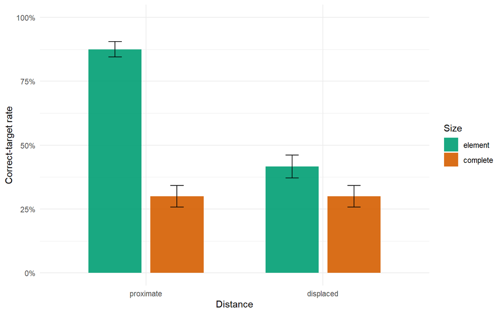

**Figure 1.** Communicative success rate by size and distance (bars are ±1 binomial SE).

## 3.3 Participant variability

The models carry by-producer and by-guesser random effects. This is the raw spread they absorb.

```r
producer_success <- df %>%
  group_by(id = producer) %>%
  summarise(role = "producer", n = n(),
            rate = mean(correct_target),
            se   = sqrt(rate * (1 - rate) / n), .groups = "drop")

guesser_success <- df %>%
  group_by(id = guesser) %>%
  summarise(role = "guesser", n = n(),
            rate = mean(correct_target),
            se   = sqrt(rate * (1 - rate) / n), .groups = "drop")

participant_success <- bind_rows(producer_success, guesser_success) %>%
  mutate(role = factor(role, levels = c("producer", "guesser")))

prod_rate_range  <- range(producer_success$rate)
guess_rate_range <- range(guesser_success$rate)
```

Producer success rates ranged from 0% to 87.5% and guesser rates from 0% to 87.5%. With a median of 8 productions per participant these per-person estimates are noisy, which is what partial pooling addresses.

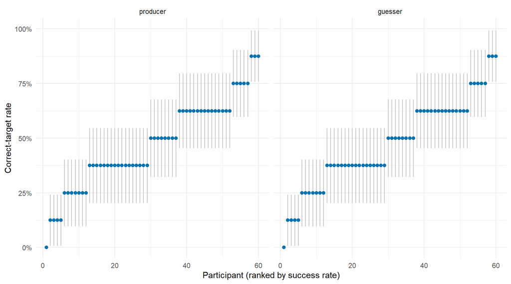

**Figure 2.** Per-participant communicative success rate, ranked within role (points ±1 binomial SE). Spread previews the by-producer and by-guesser random effects; wide bars reflect few productions per participant.

## 3.4 Success by referent

```r
success_by_item <- df %>%
  group_by(story_id, target, size, distance) %>%
  summarise(n = n(),
            rate = mean(correct_target),
            se   = sqrt(rate * (1 - rate) / n), .groups = "drop")

# scalars for inline use
hardest_item <- success_by_item %>% slice_min(rate, n = 1, with_ties = FALSE)
easiest_item <- success_by_item %>% slice_max(rate, n = 1, with_ties = FALSE)

success_by_item %>% arrange(rate)
```

| story_id | target | size | distance | n | rate | se |
| --- | --- | --- | --- | --- | --- | --- |
| cd1 | house | complete | displaced | 30 | 0.06666667 | 0.04554200 |
| cd2 | attic | complete | displaced | 30 | 0.16666667 | 0.06804138 |
| cp1 | room | complete | proximate | 30 | 0.20000000 | 0.07302967 |
| cp4 | city | complete | proximate | 30 | 0.20000000 | 0.07302967 |
| ed3 | tree | element | displaced | 30 | 0.23333333 | 0.07722022 |
| cp3 | laboratory | complete | proximate | 30 | 0.26666667 | 0.08073734 |
| cd4 | countryside | complete | displaced | 30 | 0.33333333 | 0.08606630 |
| ed4 | carpet | element | displaced | 30 | 0.36666667 | 0.08798148 |
| ed2 | sofa | element | displaced | 30 | 0.50000000 | 0.09128709 |
| cp2 | basement | complete | proximate | 30 | 0.53333333 | 0.09108401 |

[output cut: 6 more lines]

The referent hardest to communicate was house (6.7%), the easiest painting (96.7%). Spread of this size across the 16 fixed referents is what the by-item random effect absorbs.

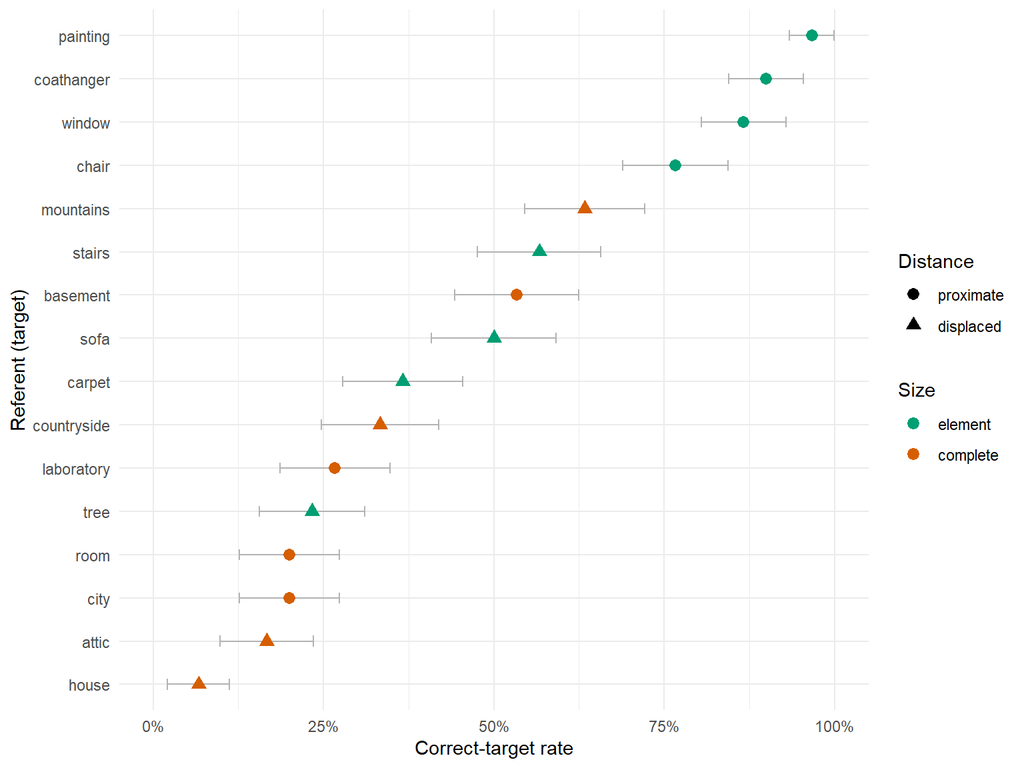

**Figure 3.** Communicative success rate per referent (points ±1 binomial SE). Colour = size (element / complete), shape = distance (dot = proximate, triangle = displaced). Each referent has a fixed size and distance, so the points fall into the four design cells; spread across the fixed 16-referent set motivates the by-item random effect.

## 3.5 Strategy use

```r
prop_icon  <- mean(df$icon)
prop_index <- mean(df$index)
prop_prop  <- mean(df$prop)

strategy_by_cell <- df %>%
  group_by(size, distance) %>%
  summarise(icon = mean(icon), index = mean(index), prop = mean(prop),
            n = n(), .groups = "drop")

# scalars: distance is the key axis for H2a/H2b
icon_prox  <- mean(df$icon[df$distance == "proximate"])
icon_disp  <- mean(df$icon[df$distance == "displaced"])
index_prox <- mean(df$index[df$distance == "proximate"])
index_disp <- mean(df$index[df$distance == "displaced"])

strategy_by_cell
```

| size | distance | icon | index | prop | n |
| --- | --- | --- | --- | --- | --- |
| element | proximate | 0.4750000 | 0.7583333 | 0.55833333 | 120 |
| element | displaced | 0.9083333 | 0.2833333 | 0.17500000 | 120 |
| complete | proximate | 0.7333333 | 0.2833333 | 0.02500000 | 120 |
| complete | displaced | 0.9000000 | 0.3666667 | 0.01666667 | 120 |

Marginally, icon was used on 75.4% of productions, index on 42.3%, and the unregistered prop on 19.4%. Across the distance contrast that H2a/H2b concern, icon use went from 60.4% (proximate) to 90.4% (displaced), and index use from 52.1% (proximate) to 32.5% (displaced) - the pattern H2a (displaced → more icon) and H2b (proximate → more index) predict.

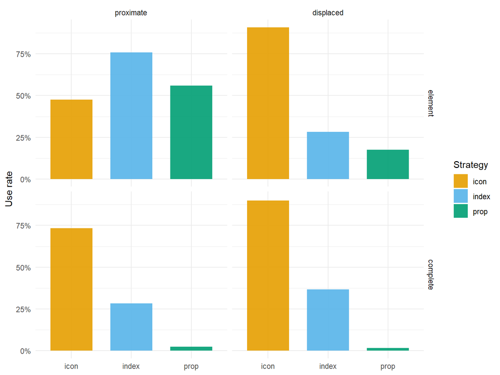

**Figure 4.** Strategy use rate by strategy, faceted by size and distance.

## 3.6 Icon-index co-occurrence

The reason the strategy analysis splits into two Bernoullis: icon and index are not complementary. This is the model-free view of how often they co-occur, and whether co-occurrence tracks the design - the question the exploratory categorical model would formalise.

```r
prop_both <- mean(df$icon == 1 & df$index == 1)

cooccur_tab <- df %>%
  count(icon, index, name = "n") %>%
  mutate(prop = n / sum(n))

# four-way configuration of the icon x index pattern (prop handled separately)
df <- df %>%
  mutate(strategy_combo = case_when(
    icon == 1 & index == 1 ~ "both",
    icon == 1 & index == 0 ~ "icon_only",
    icon == 0 & index == 1 ~ "index_only",
    icon == 0 & index == 0 ~ "neither"
  ) %>% factor(levels = c("neither", "icon_only", "index_only", "both")))

combo_by_cell <- df %>%
  count(size, distance, strategy_combo, name = "n") %>%
  group_by(size, distance) %>%
  mutate(prop = n / sum(n)) %>%
  ungroup()

cooccur_tab
```

| icon | index | n | prop |
| --- | --- | --- | --- |
| 0 | 0 | 40 | 0.08333333 |
| 0 | 1 | 78 | 0.16250000 |
| 1 | 0 | 237 | 0.49375000 |
| 1 | 1 | 125 | 0.26041667 |

Icon and index were coded on the same production in 26% of cases. Whether that layering concentrates in particular cells is what the figure below shows and the categorical model would test. (Note: `neither` is defined on icon × index only, so it includes prop-only productions.)

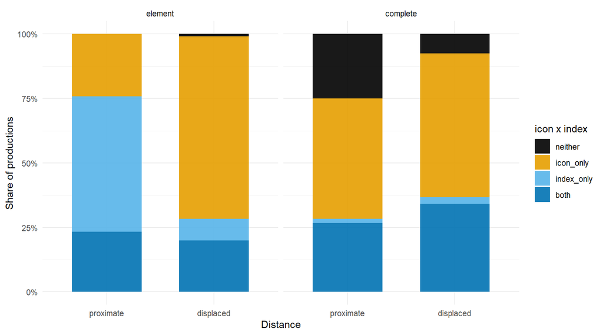

**Figure 5.** Distribution of the icon x index configuration across the 2x2 design - the model-free view the exploratory categorical model formalises.

## 3.7 Success by strategy configuration

```r
success_by_combo <- df %>%
  group_by(strategy_combo) %>%
  summarise(n = n(),
            rate = mean(correct_target),
            se   = sqrt(rate * (1 - rate) / n), .groups = "drop")

success_by_combo
```

| strategy_combo | n | rate | se |
| --- | --- | --- | --- |
| neither | 40 | 0.0500000 | 0.03446012 |
| icon_only | 237 | 0.3924051 | 0.03171759 |
| index_only | 78 | 0.8076923 | 0.04462457 |
| both | 125 | 0.5520000 | 0.04447885 |

This is descriptive of the `icon` and `index` covariates that enter Model B; it is not itself a test.

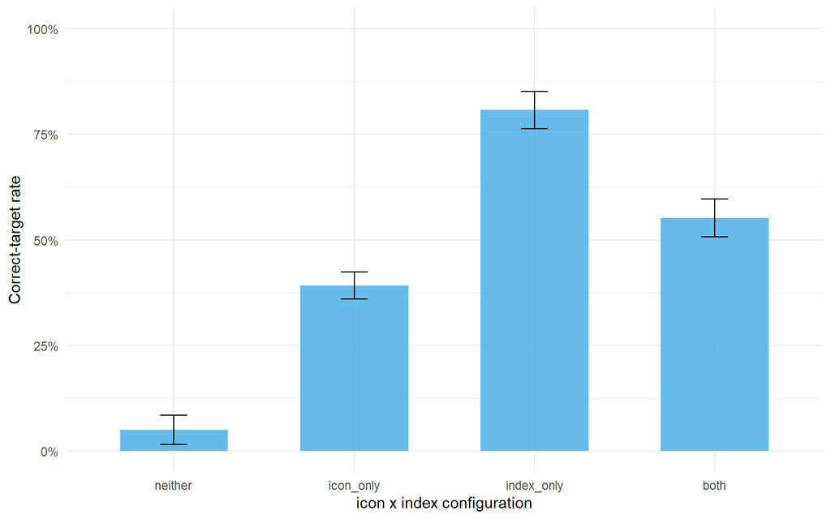

# 4 Export prepared data

The prepared frame feeds `3_modeling.Rmd`. Saved as `.rds` to preserve factor levels (and any contrasts set later); a `.csv` copy is written for inspection. Redundant helper columns are dropped first.

```r
df <- df %>% select(-guesser_slot, -success_recorded, -strategy_coded)

saveRDS(df,  paste0(data, "df_prepared.rds"))
write_csv(df, paste0(data, "df_prepared.csv"))
```